# Gene expression patterns of breast carcinomas distinguish tumor subclasses

Juan Manuel Vega Arias

26 de December, 2018

# Gene expression patterns of breast carcinomas distinguish tumor subclasses.

En esta actividad vamos a realizar un informe que analiza un caso basado en los datos del artículo:

**Gene expression patterns of breast carcinomas distinguish tumor subclasses with clinical im- plications. Sorlie et al. Proceedings of the National Academy of Sciences 98 (septiembre): 10869-74 El propósito de este artículo fue clasificar los carcinomas de mama basados en las variaciones en los patrones de expresión génica obtenidos de microarrays de cDNA y correlacionar las características del tumor con el resultado clínico**. (Sørlie et al. 2001).

Se estudian 5 tipos de cánceres:

1: basal-like (14 observaciones)

2: ERBB2+ (11 observaciones)

3: Normal (13 observaciones)

4: Luminal B/C (15 observaciones)

5: Luminal A (32 observaciones)

Nos basaremos en los análisis del capítulo 7 del libro Machine Learning With R “Black Box Methods – Neural Networks and Support Vector Machines” (Lantz 2015).

En esta actividad se usan los datos del artículo para implementar el algoritmo de red neuronal artificial (ANN) y el “support vector machine” (SVM) para predecir los cinco tipos de cánceres.

# Algoritmo Red Neuronal Artificial

Las redes neuronales artificiales fueron diseñadas como modelos computacionales de neuronas humanas y al igual que el cerebro se compone de las neuronas, las redes neuronales se componen de unos nodos, que funcionan conectados unos a otros formando una red de capas estratificadas, esta red de nodos trabaja conjuntamente para estimar un modelo que se ajuste a un problema, normalmente no lineal, con el mínimo error posible.

Tenemos varios puntos principales que caracterizan una red neuronal:

**La estructura**. Las redes neuronales se estructuran por capas en forma de una columna de nodos. La primera capa es la **Capa de Input**, seguida de las **Capas Intermedias**, a partir de la segunda capa, son las llamadas **Capas Ocultas** (Hidden Layers) y la última, es la **Capa de Output**. Aunque siempre tendremos una Capa de Input y una Capa de Output, puede haber más de una Capa Oculta.

**La funcion de activación** Cada nodo tiene una función de activación. Esta es la responsable de calcular los valores de output del nodo basados en los valores de input. Normalmente con esta conseguimos transformar el modelo de lineal a no lineal. este output será a su vez input de los nodos a los que esté conectado.

**El método de entrenamiento** Al dar un valor predecido en la capa de output, este se compara con el set de entrenamiento para saber cuánto nos hemos equivocado en nuestra predicción. Gracias al algoritmo de **backpropagation** se realizan pequeños cambios en los pesos de los valores de input para hacer coincidir la predicción con el output.

Gracias a esto las redes neuronales pueden ajustar sus predicciones a patrones no lineales que son a la vez más complejos y más parecidos a los que se dan en condiciones naturales. Dicha capacidad para extraer patrones complejos está directamente relacionada con el número de capas que formen el modelo.

| **Fortalezas** | **Debilidades** |
| --- | --- |
| • Adaptable a clasificación o problemas de predicción numérica | • Requiere de gran potencia computacional y en general es de aprendizaje lento, particularmente si la topología es compleja |
| • Capaz de modelar patrones más complejos que casi cualquier otro algoritmo | • Propenso a sobreajustar los datos de entrenamiento |
| • No necesita muchas restricciones acerca de las relaciones subyacentes de los datos | • Es un modelo de caja negra complejo que es difícil, si no imposible, de interpretar |

## Paso 1 - recolección de datos

El análisis de componentes principales (PCA, en inglés) es una técnica básica y muy utilizada en análisis multivariante para reducir el número de variables creando nuevas variables como combinación lineal de las originales buscando máximizar la varianza explicada. Usaremos el archivo fruto de un PCA a los datos brutos del artículo, “pcaComponents2.csv”.

```r
pca <- read.csv("pcaComponents2.csv")
clases <- read.csv("class2.csv")
dim(pca)
```

```
## [1] 85 85
```

```r
dim(clases)
```

```
## [1] 85  1
```

Lo primero que podemos ver en los dos conjuntos de datos es que el resultado del PCA tiene 85 observaciones y 85 variables de las cuales tendremos que elegir las 10 primeras variables que son las que representan más variabilidad entre los datos. El segundo conjunto son las clases de cáncer representados por numeros del 1 al 5 y tiene 85 observaciones como cabe esperar.

```r
pca <- pca[,1:10]
```

## Paso 2 - exploración y preparación de datos

Echamos un primer vistazo al set de datos con la función `summary()` y vemos que lo primero que necesitamos es normalizar los datos.

```r
summary(pca)
```

```
##       PC1                PC2                PC3
##  Min.   :-16.9593   Min.   :-17.7652   Min.   :-15.085
##  1st Qu.: -4.1835   1st Qu.: -5.0918   1st Qu.: -2.780
##  Median : -0.1294   Median : -0.8848   Median :  1.229
##  Mean   :  0.0000   Mean   :  0.0000   Mean   :  0.000
##  3rd Qu.:  4.3821   3rd Qu.:  6.3889   3rd Qu.:  3.864
##  Max.   : 17.1166   Max.   : 14.3018   Max.   :  8.598
##       PC4                PC5                PC6
##  Min.   :-11.7014   Min.   :-10.5730   Min.   :-7.7636
##  1st Qu.: -2.6497   1st Qu.: -1.9227   1st Qu.:-2.8514
##  Median : -0.6544   Median :  0.1247   Median :-0.6017
##  Mean   :  0.0000   Mean   :  0.0000   Mean   : 0.0000
##  3rd Qu.:  3.0395   3rd Qu.:  1.9285   3rd Qu.: 3.0075
##  Max.   : 12.2180   Max.   : 10.3548   Max.   :13.2501
##       PC7                PC8                PC9               PC10
##  Min.   :-8.52235   Min.   :-8.69123   Min.   :-8.6207   Min.   :-7.4438
##  1st Qu.:-2.62583   1st Qu.:-1.91639   1st Qu.:-2.4341   1st Qu.:-1.6976
##  Median : 0.03936   Median : 0.09771   Median : 0.2819   Median : 0.4427
##  Mean   : 0.00000   Mean   : 0.00000   Mean   : 0.0000   Mean   : 0.0000
##  3rd Qu.: 2.50151   3rd Qu.: 2.60820   3rd Qu.: 2.3424   3rd Qu.: 1.8880
##  Max.   : 8.98324   Max.   : 9.27887   Max.   : 6.7211   Max.   : 8.7419
```

Para ello vamos a crear una función a la que llamaremos `normalizar()` y utilizaremos la función `lapply()` para transformar todos los registros de nuestro set de datos.

```r
normalizar <- function(x) {
return((x - min(x)) / (max(x) - min(x)))
}
pca_norm <- as.data.frame(lapply(pca, normalizar))
```

Volvemos a ver el resumen de las variables con `summary()` y comprobamos que están todas normalizadas.

```r
summary(pca_norm)
```

```
##       PC1              PC2              PC3              PC4
##  Min.   :0.0000   Min.   :0.0000   Min.   :0.0000   Min.   :0.0000
##  1st Qu.:0.3749   1st Qu.:0.3952   1st Qu.:0.5196   1st Qu.:0.3784
##  Median :0.4939   Median :0.5264   Median :0.6888   Median :0.4618
##  Mean   :0.4977   Mean   :0.5540   Mean   :0.6369   Mean   :0.4892
##  3rd Qu.:0.6263   3rd Qu.:0.7532   3rd Qu.:0.8001   3rd Qu.:0.6163
##  Max.   :1.0000   Max.   :1.0000   Max.   :1.0000   Max.   :1.0000
##       PC5              PC6              PC7              PC8
##  Min.   :0.0000   Min.   :0.0000   Min.   :0.0000   Min.   :0.0000
##  1st Qu.:0.4133   1st Qu.:0.2338   1st Qu.:0.3368   1st Qu.:0.3770
##  Median :0.5112   Median :0.3408   Median :0.4891   Median :0.4891
##  Mean   :0.5052   Mean   :0.3695   Mean   :0.4868   Mean   :0.4836
##  3rd Qu.:0.5974   3rd Qu.:0.5126   3rd Qu.:0.6297   3rd Qu.:0.6288
##  Max.   :1.0000   Max.   :1.0000   Max.   :1.0000   Max.   :1.0000
##       PC9              PC10
##  Min.   :0.0000   Min.   :0.0000
##  1st Qu.:0.4032   1st Qu.:0.3550
##  Median :0.5803   Median :0.4872
##  Mean   :0.5619   Mean   :0.4599
##  3rd Qu.:0.7146   3rd Qu.:0.5765
##  Max.   :1.0000   Max.   :1.0000
```

**Utilizando la semilla aleatoria 12345, mezclamos las filas.**

```r
set.seed(12345)
shuffle <- sample(nrow(pca_norm),nrow(pca_norm))
pca_norm <- pca_norm[shuffle,]
clases <- clases[shuffle,]
```

Creamos un factor con 5 etiquetas, “BASLIK”, “ERBB”, “NORM”, “LUM_BC” y “LUM_A”, cada una para un tipo de cáncer, para una mejor intuición de los datos de clase de tumor y como la función `neuralnet()` no admite variables factor o categóricas, hay que transformar la variable de tipo de cáncer “`x`” a binaria, “VERDADERO” cuando pertenezaca a dicha clase y “FALSO” en caso contrario.

```r
xclases <- factor(clases, levels=c(1,2,3,4,5), labels=c("BASLIK", "ERBB", "NORM", "LUM_BC", "LUM_A"))
table(xclases)
```

```
## xclases
## BASLIK   ERBB   NORM LUM_BC  LUM_A
##     14     11     13     15     32
```

```r
pca_completa <- pca_norm
pca_completa$BASLIK <- xclases== "BASLIK"
pca_completa$ERBB <- xclases == "ERBB"
pca_completa$NORM <- xclases == "NORM"
pca_completa$LUM_BC <- xclases == "LUM_BC"
pca_completa$LUM_A <- xclases == "LUM_A"
```

Separamos los datos en dos partes, una parte para training (67%) y una parte para test (33%).

```r
pca_entreno <- pca_completa[1:57,]
pca_prueba <- pca_completa[58:85,]
```

## Paso 3 - entrenamiento del modelo sobre los datos

Preparamos la ANN. Empezaremos entrenando una simple MLP feedforward. Vamos a crear dos modelos de red neuronal artificial de una sola capa: un nodo y tres nodos. Antes de utilizar la función `neuralnet()` utilizamos como semilla generadora de los pesos iniciales el valor de `set.seed(1234567)`.

Empezamos con el modelo de 1 nodo en la capa oculta con el argumento `hidden = 1`.

```r
set.seed(1234567)
cancer_model <- neuralnet( BASLIK + ERBB + NORM + LUM_BC + LUM_A ~ PC1 +PC2 + PC3 + PC4 + PC5 + PC6 + PC7 + PC8 + PC9 + PC10, data = pca_entreno, hidden = 1)
```

La representamos gráficamente:

```r
plot(cancer_model)
```

[output not shown]

## Paso 4 - evaluación del funcionamiento del modelo

Usaremos el set de datos de `pca_prueba` para evaluar los resultados del modelo con la función `compute()`

```r
resultado_modelo <- compute(cancer_model, pca_prueba[1:10])
# De los dos componentes que retorna la función compute() utilizamos $net.result que almacena los valores previstos
cancer_prevision <- resultado_modelo$net.result
```

Ahora necesitamos saber cual de las predicciones ha sido la mayor para cada tipo de cáncer y pasar el resultado de numérico a categórico. Vamos a crear una función para hallar el máximo valor de cada predicción y ese será el resultado de la predicción de la clase de cáncer del modelo. Usaremos también la función `apply()` para aplicarla al set de datos `cancer_prevision` al completo.

```r
valormaximo <- function(x) {
  return(which(x == max(x)))
}


claseReal <- clases[58:85]
cancertipo <- apply(cancer_prevision, 1, valormaximo)
pre <- factor(cancertipo,levels=c(1,2,3,4,5),labels=c("BASLIK", "ERBB", "NORM", "LUM_BC", "LUM_A"))
class <- factor(claseReal,levels=c(1,2,3,4,5),labels=c("BASLIK", "ERBB", "NORM", "LUM_BC", "LUM_A"))
results <- table(pre,class)
```

Con la funcion `confusionMatrix()` del paquete `caret`.

```r
matrizconfu <- confusionMatrix(results)
matrizconfu
```

```
## Confusion Matrix and Statistics
##
##         class
## pre      BASLIK ERBB NORM LUM_BC LUM_A
##   BASLIK      0    0    0      0     0
##   ERBB        0    0    0      0     0
##   NORM        0    0    0      0     0
##   LUM_BC      5    5    2      3     2
##   LUM_A       0    0    1      1     9
##
## Overall Statistics
##
##                Accuracy : 0.4285714
##                  95% CI : (0.2446239, 0.6282064)
##     No Information Rate : 0.3928571
##     P-Value [Acc > NIR] : 0.4182434
##
##                   Kappa : 0.2470588
##  Mcnemar's Test P-Value : NA
##
## Statistics by Class:
##
##                      Class: BASLIK Class: ERBB Class: NORM Class: LUM_BC
## Sensitivity              0.0000000   0.0000000   0.0000000     0.7500000
## Specificity              1.0000000   1.0000000   1.0000000     0.4166667
## Pos Pred Value                 NaN         NaN         NaN     0.1764706
## Neg Pred Value           0.8214286   0.8214286   0.8928571     0.9090909
## Prevalence               0.1785714   0.1785714   0.1071429     0.1428571
## Detection Rate           0.0000000   0.0000000   0.0000000     0.1071429
## Detection Prevalence     0.0000000   0.0000000   0.0000000     0.6071429
## Balanced Accuracy        0.5000000   0.5000000   0.5000000     0.5833333
##                      Class: LUM_A
## Sensitivity             0.8181818
## Specificity             0.8823529
## Pos Pred Value          0.8181818
## Neg Pred Value          0.8823529
## Prevalence              0.3928571
## Detection Rate          0.3214286
## Detection Prevalence    0.3928571
## Balanced Accuracy       0.8502674
```

Vemos los distintos valores estadísticos como la precisión que es de 0.43 y el estadístico $\kappa$ = 0.25.

## Paso 5 - mejora de resultados del modelo

Para mejorar el rendimiento del algoritmo vamos a crear el modelo con tres nodos con el argumento `hidden = 3`. Volvemos a utilizar la semilla para los datos pseudoaleatorios `set.seed(1234567)`.

```r
set.seed(1234567)
cancer_model2 <- neuralnet( BASLIK + ERBB + NORM + LUM_BC + LUM_A ~ PC1 +PC2 + PC3 + PC4 + PC5 + PC6 + PC7 + PC8 + PC9 + PC10, data = pca_entreno, hidden = 3)
```

La representamos gráficamente:

```r
plot(cancer_model2)
```

[output not shown]

Evaluamos el modelo como en la red anterior.

```r
resultado_modelo2 <- compute(cancer_model2, pca_prueba[1:10])
# De los dos componentes que retorna la función compute() utilizamos $net.result que almacena los valores previstos
cancer_prevision2 <- resultado_modelo2$net.result
```

Obtenemos la matrix de confusión

```r
cancertipo2 <- apply(cancer_prevision2, 1, valormaximo)
pre2 <- factor(cancertipo2,levels=c(1,2,3,4,5),labels=c("BASLIK", "ERBB", "NORM", "LUM_BC", "LUM_A"))
results2 <- table(pre2,class)
matrizconfu2 <- confusionMatrix(results2)
matrizconfu2
```

```
## Confusion Matrix and Statistics
##
##         class
## pre2     BASLIK ERBB NORM LUM_BC LUM_A
##   BASLIK      5    4    0      0     0
##   ERBB        0    0    0      0     0
##   NORM        0    0    2      0     1
##   LUM_BC      0    1    0      3     2
##   LUM_A       0    0    1      1     8
##
## Overall Statistics
##
##                Accuracy : 0.6428571
##                  95% CI : (0.4406503, 0.8135933)
##     No Information Rate : 0.3928571
##     P-Value [Acc > NIR] : 0.006524356
##
##                   Kappa : 0.5302013
##  Mcnemar's Test P-Value : NA
##
## Statistics by Class:
##
##                      Class: BASLIK Class: ERBB Class: NORM Class: LUM_BC
## Sensitivity              1.0000000   0.0000000  0.66666667     0.7500000
## Specificity              0.8260870   1.0000000  0.96000000     0.8750000
## Pos Pred Value           0.5555556         NaN  0.66666667     0.5000000
## Neg Pred Value           1.0000000   0.8214286  0.96000000     0.9545455
## Prevalence               0.1785714   0.1785714  0.10714286     0.1428571
## Detection Rate           0.1785714   0.0000000  0.07142857     0.1071429
## Detection Prevalence     0.3214286   0.0000000  0.10714286     0.2142857
## Balanced Accuracy        0.9130435   0.5000000  0.81333333     0.8125000
##                      Class: LUM_A
## Sensitivity             0.7272727
## Specificity             0.8823529
## Pos Pred Value          0.8000000
## Neg Pred Value          0.8333333
## Prevalence              0.3928571
## Detection Rate          0.2857143
## Detection Prevalence    0.3571429
## Balanced Accuracy       0.8048128
```

Podemos observar que la precisión a es de 0.64 Y el valor $\kappa =$ 0.53 para el modelo de tres nodos.

## 3-fold crossvalidation

Ahora vamos a usar el paquete `caret` y `nnet()` para realizar un nuevo modelo de 1, 3 y 5 nodos con 3-fold crossvalidation.

```r
newpca <- pca_norm
newpca$clase <- xclases
```

Para ello creamos un nuevo set de datos compuesto de las 10 primeras componentes principales y la clase de cáncer de las 85 observaciones.

```r
head(newpca)
```

```
##             PC1          PC2          PC3          PC4          PC5
## 62 0.4568885062 0.3757431715 0.8638260417 0.3725201816 0.2282818165
## 74 0.5098898403 0.4343383792 0.8423921915 0.5831678048 0.3632629398
## 64 0.4422248629 0.2190160037 0.5290506791 0.5296746708 0.1628558212
## 73 0.6039317510 0.3952172206 0.7318473832 0.1874584593 0.6575328668
## 37 0.7095357660 0.5686974742 0.8777052797 0.4502938107 0.3394416095
## 14 0.2234494377 0.5963101412 0.7095403594 0.4168730594 0.9347491423
##             PC6          PC7           PC8          PC9         PC10
## 62 0.2887052443 0.3377068702 0.21660341503 0.5612007165 0.5188871636
## 74 0.7481763754 0.6651012804 0.41824144343 0.4861580815 0.5638014689
## 64 0.1752947070 0.5449205185 0.33439051848 0.0000000000 0.2592441438
## 73 0.5799871829 0.3030868982 0.05162510565 0.9000658013 0.6528653482
## 37 0.5754288320 0.6380042822 0.40438342096 0.6631286302 0.3910243535
## 14 0.6230892812 0.7353053025 0.43185163954 0.7419480880 1.0000000000
##     clase
## 62  LUM_A
## 74  LUM_A
## 64  LUM_A
## 73  LUM_A
## 37   NORM
## 14 BASLIK
```

Seguidamente hacemos el modelo de entrenamiento 3-fold crossvalidation aplicando la semilla pseudoaleatoria.

```r
set.seed(1234567)
newmodel <- train(clase ~ ., newpca, method='nnet',
               trControl= trainControl(method='cv', number=3),
               tuneGrid= NULL, tuneLength=3 ,trace = FALSE)
newmodel
```

```
## Neural Network
##
## 85 samples
## 10 predictors
##  5 classes: 'BASLIK', 'ERBB', 'NORM', 'LUM_BC', 'LUM_A'
##
## No pre-processing
## Resampling: Cross-Validated (3 fold)
## Summary of sample sizes: 57, 55, 58
## Resampling results across tuning parameters:
##
##   size  decay   Accuracy      Kappa
##   1     0.0000  0.4449735450  0.2593079273
##   1     0.0001  0.4811287478  0.2999492132
##   1     0.1000  0.5517636684  0.3677815597
##   3     0.0000  0.6353615520  0.5109465908
##   3     0.0001  0.7375661376  0.6586025765
##   3     0.1000  0.8355379189  0.7800308703
##   5     0.0000  0.7423280423  0.6692462263
##   5     0.0001  0.7631393298  0.6922996785
##   5     0.1000  0.8223104056  0.7617269983
##
## Accuracy was used to select the optimal model using the largest value.
## The final values used for the model were size = 3 and decay = 0.1.
```

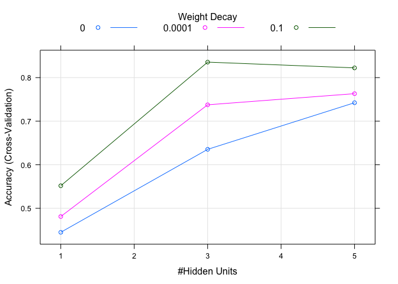

```r
plot(newmodel)
```

Finalmente podemos ver que el modelo obtenido con el 3-fold crossvalidation de la función `nnet()` con unos valores de 3, 0.1 número de nodos y decay respectivamente, es mejor que el obtenido con la ANN de 3 nodos de la función `neuralnet()`. Con una precisión de 0.8355379189 y un estadístico $\kappa$ = 0.7800308703.

# Algoritmo Support Vector Machine

Un SMV puede ser imaginado como una superficie que crea un límite entre puntos de datos graficados multidimensionalmente que representan ejemplos y los valores de sus características. La meta de un SVM es crear una separación llamada hiperplano, que divide el espacio para crear particiones homogéneas a cada lado de este creando así grupos diferentes cada uno con características parecidas. Las SVM combinan aspectos de la clasificación por k-NN y de los métodos de regresión, permitiendo el modelado de relaciones altamente complejas.

| **Fortalezas** | **Debilidades** |
| --- | --- |
| • Se puede usar para problemas de clasificación o predicción numérica | • Encontrar el mejor modelo requiere probar diferentes kernels y parámetros del modelo (prueba y error) |
| • Funciona bastante bien con datos ruidosos y no es muy propenso al overfitting | • Lento de entrenar, sobre todo a medida que aumenta el número de características |
| • Puede ser más fácil de usar que las redes neuronales, en particular debido a la existencia de varios algoritmos SVM bien soportados | • Es un modelo de caja negra, estos son muy complejos por lo que difíciles, si no imposibles, de interpretar |
| • Gana popularidad debido a su alta precisión y ganancias de alto perfil en competiciones de minería de datos |  |

## Paso 1 - recolección de datos

Los datos se obtienen esta vez de los datos de expresión génica originales. El fichero con la información se llama data2.csv.

```r
datosorig <- read.csv("data2.csv")
dim(datosorig)
```

```
## [1]  85 456
```

Los datos originales se componen de 85 observaciones y 456 ya que estos datos no han sido transformados por PCA, sin embargo, nos servirán igual ya que entrenar una SVM es mucho más rápido que una ANN por lo que nos podemos permitir tener muchísimas más características con una capacidad de computo relativamente baja.

Como en la preparación del modelo anterior, también usaremos el set de datos de `class2.csv` que clasifica cada una de las observaciones en un tipo de tumor.

## Paso 2 - exploración y preparación de datos

El primer paso será mezclar las filas con la misma semilla pseudoaleatoria `set.seed(12345)` el set de datos de `data2.csv` y añadir el set de datos de `clase2.csv` como hemos hecho anteriormente, en forma de factor.

```r
datosorig <- datosorig[shuffle,]
datosorig$clase <- xclases
```

Para hacernos una idea de la estructura de nuestros datos a modo ilustrativo vamos a ver algunas cifras de las primeras 6 características de nuestro set de datos. Para ello usaremos la función `str()` y `summary()`.

```r
str(datosorig[1:4,1:6])
```

```
## 'data.frame':    4 obs. of  6 variables:
##  $ V1: num  2.54 0.32 -1.17 1.76
##  $ V2: num  0.06 0.15 0.87 -0.36
##  $ V3: num  0.26 -0.72 -1.13 -0.08
##  $ V4: num  0.288 -1.21 0.03 -1.18
##  $ V5: num  1.1 1.19 1.53 -4.7
##  $ V6: num  0.65 1.55 1.73 -2.15
```

```r
summary(datosorig[,1:6])
```

```
##        V1                   V2                V3
##  Min.   :-6.0700000   Min.   :-2.5400   Min.   :-2.7600000
##  1st Qu.:-0.7600000   1st Qu.:-0.5900   1st Qu.:-0.5000000
##  Median :-0.0200000   Median :-0.0800   Median :-0.0140000
##  Mean   :-0.1209647   Mean   :-0.1066   Mean   : 0.1147412
##  3rd Qu.: 0.6700000   3rd Qu.: 0.3600   3rd Qu.: 0.4300000
##  Max.   : 2.5400000   Max.   : 1.8600   Max.   : 4.1400000
##        V4                    V5                   V6
##  Min.   :-3.42000000   Min.   :-4.7000000   Min.   :-4.67000000
##  1st Qu.:-1.09000000   1st Qu.:-0.9000000   1st Qu.:-0.80000000
##  Median : 0.00000000   Median :-0.0800000   Median :-0.03000000
##  Mean   : 0.04170588   Mean   :-0.1483412   Mean   :-0.08735294
##  3rd Qu.: 1.40000000   3rd Qu.: 1.0100000   3rd Qu.: 0.91000000
##  Max.   : 4.15000000   Max.   : 3.6100000   Max.   : 3.40000000
```

Las SVM requieren que todas las características sean numéricas y sobre todo que estén escaladas a intervalos pequeños, sin embargo no necesitaremos normalizar los datos ya que el paquete que usaremos se encargará automáticamente de ello.

Ahora pasamos a preparar los sets de entreno y prueba.

```r
datosorig_entreno <- datosorig[1:57,]
datosorig_prueba <- datosorig[58:85,]
```

## Paso 3 - entrenamiento del modelo sobre los datos

Usaremos la función `ksvm()` del paquete `kernlab`, previamente instalado y como argumento de `kernel = "vanilladot"` para la función lineal.

```r
set.seed(1234567)
clasificador_cancer <- ksvm(clase ~ ., data = datosorig_entreno, kernel = "vanilladot")
clasificador_cancer
```

```
## Support Vector Machine object of class "ksvm"
##
## SV type: C-svc  (classification)
##  parameter : cost C = 1
##
## Linear (vanilla) kernel function.
##
## Number of Support Vectors : 49
##
## Objective Function Value : -0.0088 -0.0085 -0.0091 -0.008 -0.0118 -0.0165 -0.0149 -0.0117 -0.014 -0.0297
## Training error : 0
```

## Paso 4 - evaluación del funcionamiento del modelo

Esta información nos dice más bien poco de como clasificará nuestro modelo otros casos del mundo real. Necesitamos examinar su rendimiento con el set de prueba. Para ello usaremos la función `predict()` que nos permite hacer predicciones con el set de prueba.

```r
prediccion_cancer <- predict(clasificador_cancer, datosorig_prueba)
head(prediccion_cancer)
```

```
## [1] LUM_A LUM_A LUM_A ERBB  LUM_A NORM
## Levels: BASLIK ERBB NORM LUM_BC LUM_A
```

ahora comparamos el tipo de cancer resultado de la predicción del modelo con el verdadero en el set de prueba con la función `table()`.

```r
resultado <- table(prediccion_cancer, datosorig_prueba$clase)
```

hallamos la matriz de confusión con la función `confusionMatrix()`.

```r
confusionmat <- confusionMatrix(resultado)
confusionMatrix(resultado)
```

```
## Confusion Matrix and Statistics
##
##
## prediccion_cancer BASLIK ERBB NORM LUM_BC LUM_A
##            BASLIK      5    1    0      0     0
##            ERBB        0    4    0      0     0
##            NORM        0    0    2      0     0
##            LUM_BC      0    0    1      3     0
##            LUM_A       0    0    0      1    11
##
## Overall Statistics
##
##                Accuracy : 0.8928571
##                  95% CI : (0.7177356, 0.9773349)
##     No Information Rate : 0.3928571
##     P-Value [Acc > NIR] : 0.00000005673242
##
##                   Kappa : 0.8551724
##  Mcnemar's Test P-Value : NA
##
## Statistics by Class:
##
##                      Class: BASLIK Class: ERBB Class: NORM Class: LUM_BC
## Sensitivity              1.0000000   0.8000000  0.66666667     0.7500000
## Specificity              0.9565217   1.0000000  1.00000000     0.9583333
## Pos Pred Value           0.8333333   1.0000000  1.00000000     0.7500000
## Neg Pred Value           1.0000000   0.9583333  0.96153846     0.9583333
## Prevalence               0.1785714   0.1785714  0.10714286     0.1428571
## Detection Rate           0.1785714   0.1428571  0.07142857     0.1071429
## Detection Prevalence     0.2142857   0.1428571  0.07142857     0.1428571
## Balanced Accuracy        0.9782609   0.9000000  0.83333333     0.8541667
##                      Class: LUM_A
## Sensitivity             1.0000000
## Specificity             0.9411765
## Pos Pred Value          0.9166667
## Neg Pred Value          1.0000000
## Prevalence              0.3928571
## Detection Rate          0.3928571
## Detection Prevalence    0.4285714
## Balanced Accuracy       0.9705882
```

Hemos obtenido con nuestra matriz de confusión que la precisión del modelo SVM con función lineal es 0.89 y el valor del estadístico $\kappa$ = 0.86.

## Paso 5 - mejora de resultados del modelo

Nuestro modelo de SVM usa una función de kernel lineal simple. Podríamos conseguir mapear nuestros datos en un espacio de mayores dimensiones con una función de kernel más compleja y así obtener un mejor ajuste del modelo.

Hay muchas funciones de kernel para usar, pero una convención popular es comenzar con la función Gaussian RBF kernel, así que vamos a ver que resultados obtendríamos si utilizásemos esta función en nuestro modelo.

```r
set.seed(1234567)
clasificador_cancer2 <- ksvm(clase ~ ., data = datosorig_entreno, kernel = "rbfdot")
clasificador_cancer2
```

```
## Support Vector Machine object of class "ksvm"
##
## SV type: C-svc  (classification)
##  parameter : cost C = 1
##
## Gaussian Radial Basis kernel function.
##  Hyperparameter : sigma =  0.00126613374372489
##
## Number of Support Vectors : 54
##
## Objective Function Value : -6.2012 -5.3154 -6.6367 -7.2803 -6.6349 -8.0612 -8.2053 -6.7764 -8.2928 -13.4636
## Training error : 0.017544
```

Evaluamos el rendimiento como hemos hecho anteriormente.

```r
prediccion_cancer2 <- predict(clasificador_cancer2, datosorig_prueba)
head(prediccion_cancer2)
```

```
## [1] LUM_A LUM_A LUM_A NORM  LUM_A NORM
## Levels: BASLIK ERBB NORM LUM_BC LUM_A
```

```r
resultado2 <- table(prediccion_cancer2, datosorig_prueba$clase)
confusionmat2 <- confusionMatrix(resultado2)
confusionMatrix(resultado2)
```

```
## Confusion Matrix and Statistics
##
##
## prediccion_cancer2 BASLIK ERBB NORM LUM_BC LUM_A
##             BASLIK      5    1    0      0     0
##             ERBB        0    0    0      0     0
##             NORM        0    1    2      0     0
##             LUM_BC      0    1    0      0     0
##             LUM_A       0    2    1      4    11
##
## Overall Statistics
##
##                Accuracy : 0.6428571
##                  95% CI : (0.4406503, 0.8135933)
##     No Information Rate : 0.3928571
##     P-Value [Acc > NIR] : 0.006524356
##
##                   Kappa : 0.4843462
##  Mcnemar's Test P-Value : NA
##
## Statistics by Class:
##
##                      Class: BASLIK Class: ERBB Class: NORM Class: LUM_BC
## Sensitivity              1.0000000   0.0000000  0.66666667    0.00000000
## Specificity              0.9565217   1.0000000  0.96000000    0.95833333
## Pos Pred Value           0.8333333         NaN  0.66666667    0.00000000
## Neg Pred Value           1.0000000   0.8214286  0.96000000    0.85185185
## Prevalence               0.1785714   0.1785714  0.10714286    0.14285714
## Detection Rate           0.1785714   0.0000000  0.07142857    0.00000000
## Detection Prevalence     0.2142857   0.0000000  0.10714286    0.03571429
## Balanced Accuracy        0.9782609   0.5000000  0.81333333    0.47916667
##                      Class: LUM_A
## Sensitivity             1.0000000
## Specificity             0.5882353
## Pos Pred Value          0.6111111
## Neg Pred Value          1.0000000
## Prevalence              0.3928571
## Detection Rate          0.3928571
## Detection Prevalence    0.6428571
## Balanced Accuracy       0.7941176
```

En este caso podemos decir que con el modelo de SVM con la función Gaussian RBF hemos obtenido una precisión de 0.64 y el valor del estadístico $\kappa$ = 0.48.

## 3-fold crossvalidation

Ahora usaremos de nuevo el paquete `caret` y `svmLinear` para realizar el modelo de SVM con 3-fold crossvalidation.

```r
set.seed(1234567)
newmodel2 <- train(clase ~ ., data = datosorig, method='svmLinear',
               trControl= trainControl(method='cv', number=3),
               tuneGrid= NULL, trace = FALSE)
newmodel2
```

```
## Support Vector Machines with Linear Kernel
##
##  85 samples
## 456 predictors
##   5 classes: 'BASLIK', 'ERBB', 'NORM', 'LUM_BC', 'LUM_A'
##
## No pre-processing
## Resampling: Cross-Validated (3 fold)
## Summary of sample sizes: 57, 55, 58
## Resampling results:
##
##   Accuracy      Kappa
##   0.8692239859  0.82751891
##
## Tuning parameter 'C' was held constant at a value of 1
```

Finalmente podemos ver que con el modelo con el 3-fold crossvalidation del paquete `caret` hemos obtenido unos valores de precisión de 0.8692239859 y un un estadístico $\kappa$ = 0.82751891.

## Evaluación y comparación de los resultados

**Modelo de ANN con un nodo**

*Precisión* = 0.43 / $\kappa$ = 0.25

**Modelo de ANN con tres nodos**

*Precisión* = 0.64 / $\kappa$ = 0.53

**Modelo de ANN con 3-fold crossvalidation**

Valores de 3, 0.1 número de nodos y decay respectivamente.

*Precisión* de 0.84 / $\kappa$ = 0.78

**Modelo de SVM con función lineal**

*Precisión* = 0.89 / $\kappa$ = 0.86

**Modelo de SVM con función Gaussiana**

*Precisión* = 0.64 / $\kappa$ = 0.48

**Modelo de SVM con función lineal con 3-fold crossvalidation**

*Precisión* = 0.87 / $\kappa$ = 0.83

Siendo los valores más altos de entre todos estos los de el modelo SVM con función lineal, sorprendentemente. En favor de las ANN podríamos decir que estas han sido entrenadas con datos sesgados resultados del PCA debido a los grandes tiempos de entreno que hubiésemos necesitado de haberlas entrenado con los archivos de datos originales como lo hemos hecho con las SVM.

# Referencias

Lantz, Brett. 2015. *Machine Learning with R*. 2nd ed. Packt Publishing.

Sørlie, Therese, Charles M. Perou, Robert Tibshirani, Turid Aas, Stephanie Geisler, Hilde Johnsen, Trevor Hastie, et al. 2001. “Gene Expression Patterns of Breast Carcinomas Distinguish Tumor Subclasses with Clinical Implications.” *Proceedings of the National Academy of Sciences* 98 (19). National Academy of Sciences: 10869–74. doi:10.1073/pnas.191367098.